# MLDS 401/IEMS 404-1 (Fall 2023) - Lab 7 Solution

Yayu Zhou

2023-11-14

## [Question 1] MLE for Geometric Distribution

You are working in sales. You keep calling you clients and track the number of calls you make until you get a sale: `12 19 33 17 36 22 11 2 75 13`

You are going to fit a Geometric distribution, which has a probability mass function of
$$p(z) = (1 −
\theta)^{z - 1}\theta \quad \text{if } z \geq 1$$
What is the maximum likelihood estimate of $\theta$?

For the MLE estimate, we have the following likelihood function
$$L(\theta) = \prod_{i=1}^n p(z_i) = (1 -
\theta)^{\left(\sum_{i=1}^{n}z_i - n\right)}\theta^n$$

Furthermore we take the log of the both sides:
$$\ln{L(\theta)} = \left(\sum_{i=1}^{n}z_i -
n\right) \ln(1 - \theta) + nln(\theta)$$

To maximize this function for $\theta$, we take the derivative w.r.t. $\theta$ and equate it to zero, which gives
$$\dfrac{d\ln{L(\theta)}}{d\theta} =
\dfrac{-\left(\sum_{i=1}^{n}z_i - n\right)}{1-\theta} +
\dfrac{n}{\theta} = 0$$

$$\implies \left(\sum_{i=1}^{n}z_i -
n\right)\theta = n - n\theta$$
$$\implies \theta = \dfrac{n}{\sum_{i=1}^{n}z_i} =
\dfrac{1}{\bar{X}} = \dfrac{1}{24}$$

## [7.2] Nonconvergence of MLE

### a)

We know:
$$ln L = \sum_{i = 1}^{n} y_i
(\beta_1 x_i) - \sum_{i = 1}^{n} ln[1 + exp(\beta_1 x_i)]$$
so we can get the following plot of log-likelihood function versus $\beta_1$

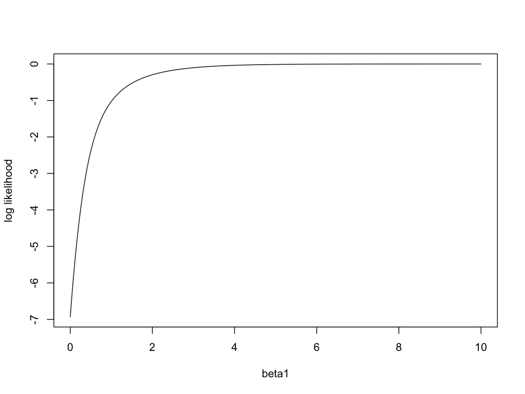

```r
# Compute log-likelihood function
logLike = function(x, y, beta){
  sum(y*(beta*x)) - sum(log(1 + exp(beta*x)))
}

# Plot
x = c(-5, -4, -3, -2, -1, 1, 2, 3, 4, 5)
y = c(0, 0, 0, 0, 0, 1, 1, 1, 1, 1)
beta = seq(0, 10, 0.01)
f = numeric(length(beta))
for (i in 1:length(f)){
  f[i] = logLike(x, y, beta[i])
}
plot(beta, f, type = "l", xlab = "beta1", ylab = "log likelihood")
```

From the plot, it is easy to see that the log-likelihood approaches 0 as $\beta_1 \rightarrow \infty$. So the MLE of $\beta_1$ does not exist and the algorithm to find it does not converge.

### b)

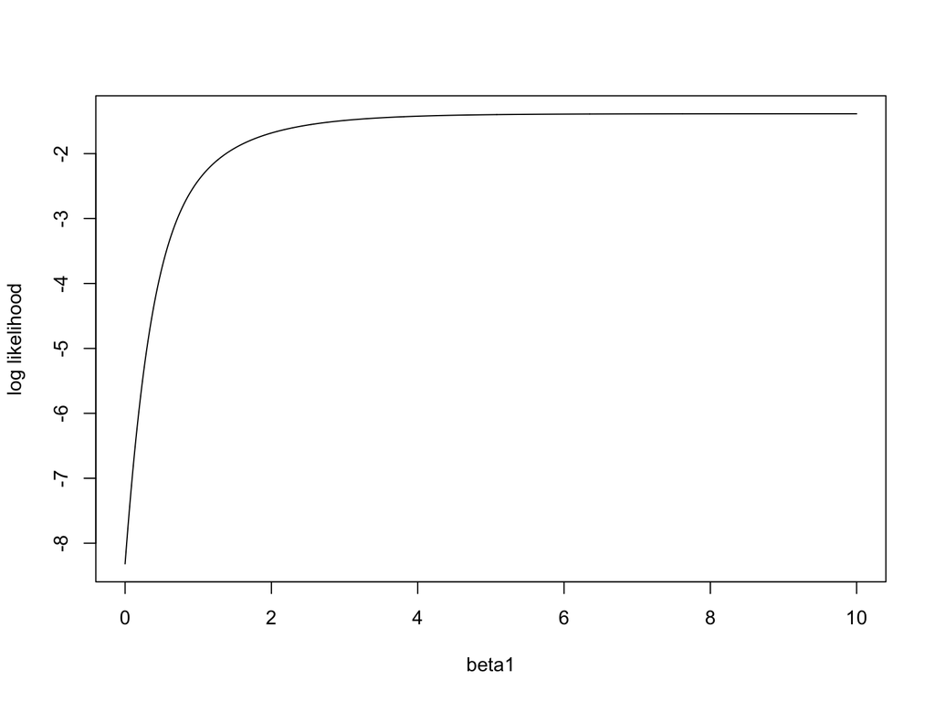

```r
## add two more obs
x = c(-5, -4, -3, -2, -1, 1, 2, 3, 4, 5, 0, 0)
y = c(0, 0, 0, 0, 0, 1, 1, 1, 1, 1, 0, 1)
beta = seq(0, 10, 0.01)
f = numeric(length(beta))
for (i in 1:length(f)){
  f[i] = logLike(x, y, beta[i])
}
plot(beta, f, type = "l", xlab = "beta1", ylab = "log likelihood")
```

From this plot, by adding two more observations, the log-likelihood function approaches to a number less than 0 as $\beta_1 \rightarrow \infty$.

## [7.8] Radiation therapy

Twenty four cancer patients were treated with radiation therapy for different number of days ($x$) and the presence ($y = 0$) or absence ($y = 1$) of tumor was observed.

```r
radiation = read.csv("~/Personal Drive/Northwestern University/Fall 2023/MLDS 401 - TA/Labs/Radiation.csv")
head(radiation)
```

```
##   Days Presence
## 1   21        1
## 2   24        1
## 3   25        1
## 4   26        1
## 5   28        1
## 6   31        1
```

### a) Fit a binary logistic regression model to the data.

```r
fit = glm(Presence ~ Days, family = binomial, data = radiation)
summary(fit)
```

```
##
## Call:
## glm(formula = Presence ~ Days, family = binomial, data = radiation)
##
## Coefficients:
##             Estimate Std. Error z value Pr(>|z|)
## (Intercept)  3.81944    1.83518   2.081   0.0374 *
## Days        -0.08648    0.04322  -2.001   0.0454 *
## ---
## Signif. codes:  0 '***' 0.001 '**' 0.01 '*' 0.05 '.' 0.1 ' ' 1
##
## (Dispersion parameter for binomial family taken to be 1)
##
##     Null deviance: 32.601  on 23  degrees of freedom
## Residual deviance: 27.788  on 22  degrees of freedom
## AIC: 31.788
##
## Number of Fisher Scoring iterations: 4
```

As the number of days of exposure increases, the odds of success (absence of tumor) decrease. This may seem counterintuitive but the amount of radiation exposure is fixed and if it is spread over more days then its effect is diluted.

### b) Calculate a 95% confidence interval for the odds of absence of tumor vs. presence of tumor if the number of days of therapy is increased by 5 days.

The difference in the log-odds of absence of tumor vs. presence of tumor if the number of days of exposure is increased by 5 days is
$$\ln{\psi(x + 5)} - \ln{\psi(x)} = \beta_0 +
\beta_1(x + 5) - \beta_0 - \beta_1 x = 5\beta_1$$
The 95% CI for $5\beta_1$ is
$$5\hat{\beta}_1 \pm 1.96\times
\text{SE}(5\hat{\beta}_1) = -5\times 0.08648 \pm 1.96\times 5\times
0.04322 = −0.4325 \pm 0.4236 = [−0.8558, −0.0086]$$
.

The 95% CI on the odds of success is
$$[exp(−0.08558), exp(−0.0086)] = [0.4249,
0.9914]$$
.

Hence the odds of success are < 1 if the number of days of exposure is increased by 5 days.

### c) Calculate the estimated success probabilities $p_i$ for the 24 patients in the sample. Find the optimum threshold $p^*$ that maximizes the correct classification rate (CCR). Calculate sensitivity, specificity and the $F_1$-score for this $p^*$.

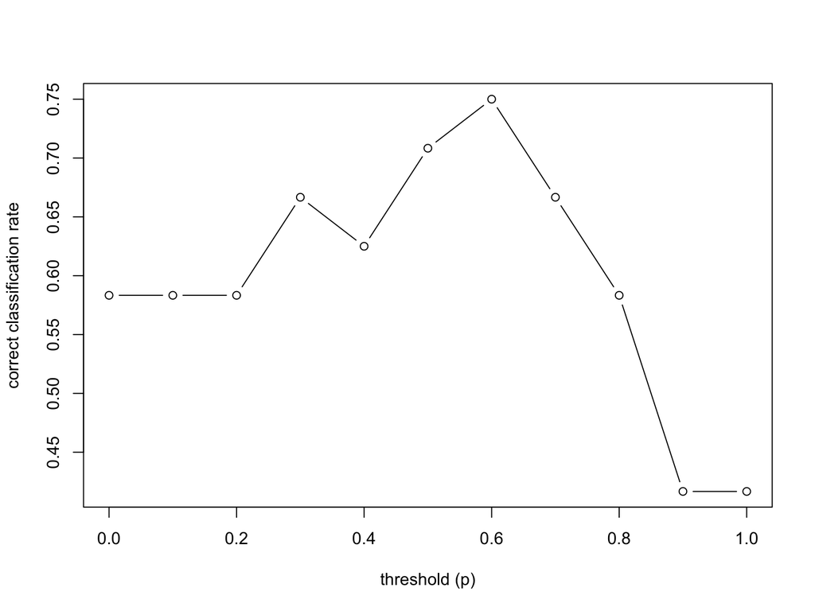

```r
# estimated probabilities
phat = predict(fit, newdata = radiation, type = "response")

p = seq(0, 1, by = 0.1)
ccr = numeric(length(p))
for(i in 1:length(p)){
  # estimated class
  yhat = ifelse(phat >= p[i], 1, 0)
  # accuracy
  ccr[i] = mean(yhat == radiation$Presence)
}
plot(p, ccr, type = "b", xlab = "threshold (p)", ylab = "correct classification rate")
```

A plot of CCR versus $p^∗$ is shown below. Note that CCR is maximized when $p^∗ = 0.6$ and the maximized CCR is $CCR^* = 0.75$.

The confusion matrix using p∗ = 0.60 is shown below. We see that the maximum CCR = 0.75.

```r
pstar = p[which.max(ccr)]
yhat = ifelse(phat >= pstar, 1, 0)
tab = table(true = radiation$Presence, pred = yhat)
tab
```

```
##     pred
## true  0  1
##    0  8  2
##    1  4 10
```

```r
ccr_star = sum(diag(tab)) / sum(tab); ccr_star
```

```
## [1] 0.75
```

```r
sensitivity = tab[2, 2]/sum(tab[2, ])
specificity = tab[1, 1]/sum(tab[1, ])
precision = tab[2, 2]/sum(tab[, 2])
recall = tab[2, 2]/sum(tab[2, ])
f1 = 2 * precision * recall / (precision + recall)
```

From this table we can calculate:

- Sensitivity $= \frac{10}{14} = 0.7143$
- Specificity $= \frac{8}{10} = 0.8$
- Precision $= \frac{10}{12} = 0.8333$
- Recall $= \frac{10}{14} = 0.7143$
- $F_1$-Score $= \frac{2PR}{P + R} = 0.7692$

## [Question 4] Program Choice Example

The goal is to model the program choices of high school students based on a variety of attributes.

- Dependent variable: `prog`. The program choices are general program, vocational program and academic program.
- Attributes:
  - `gender`: female, male
  - `ses`: social/economic status (low, middle, high)
  - `schtype`: school type (private, public)
  - `read`
  - `write`
  - `math`
  - `science`
  - `honors`: enrolled, not enrolled
  - `awards`: number of awards received
- IDs: `id`, `cid`

```r
data1 = read.csv("~/Personal Drive/Northwestern University/Fall 2023/MLDS 401 - TA/Labs/hsbdemo.csv", sep = ",", header = T)
str(data1)
```

```
## 'data.frame':    200 obs. of  13 variables:
##  $ id     : int  45 108 15 67 153 51 164 133 2 53 ...
##  $ gender : chr  "female" "male" "male" "male" ...
##  $ ses    : chr  "low" "middle" "high" "low" ...
##  $ schtyp : chr  "public" "public" "public" "public" ...
##  $ prog   : chr  "vocation" "general" "vocation" "vocation" ...
##  $ read   : int  34 34 39 37 39 42 31 50 39 34 ...
##  $ write  : int  35 33 39 37 31 36 36 31 41 37 ...
##  $ math   : int  41 41 44 42 40 42 46 40 33 46 ...
##  $ science: int  29 36 26 33 39 31 39 34 42 39 ...
##  $ socst  : int  26 36 42 32 51 39 46 31 41 31 ...
##  $ honors : chr  "not enrolled" "not enrolled" "not enrolled" "not enrolled" ...
##  $ awards : int  0 0 0 0 0 0 0 0 0 0 ...
##  $ cid    : int  1 1 1 1 1 1 1 1 1 1 ...
```

```r
head(data1)
```

```
##    id gender    ses schtyp     prog read write math science socst       honors
## 1  45 female    low public vocation   34    35   41      29    26 not enrolled
## 2 108   male middle public  general   34    33   41      36    36 not enrolled
## 3  15   male   high public vocation   39    39   44      26    42 not enrolled
## 4  67   male    low public vocation   37    37   42      33    32 not enrolled
## 5 153   male middle public vocation   39    31   40      39    51 not enrolled
## 6  51 female   high public  general   42    36   42      31    39 not enrolled
##   awards cid
## 1      0   1
## 2      0   1
## 3      0   1
## 4      0   1
## 5      0   1
## 6      0   1
```

```r
table(data1$prog)
```

```
##
## academic  general vocation
##      105       45       50
```

### 1. Fit a multinomial regression with `ses` and `write`. Choose “academic” as the reference class.

```r
data1$prog2 = relevel(factor(data1$prog), ref = "academic")

library(nnet)
fit1 = multinom(prog2 ~ ses + write, data = data1)
(summaryTab1 = summary(fit1))
```

```
## Call:
## multinom(formula = prog2 ~ ses + write, data = data1)
##
## Coefficients:
##          (Intercept)    seslow sesmiddle       write
## general     1.689478 1.1628411 0.6295638 -0.05793086
## vocation    4.235574 0.9827182 1.2740985 -0.11360389
##
## Std. Errors:
##          (Intercept)    seslow sesmiddle      write
## general     1.226939 0.5142211 0.4650289 0.02141101
## vocation    1.204690 0.5955688 0.5111119 0.02222000
##
## Residual Deviance: 359.9635
## AIC: 375.9635
```

### 2. If `write` is increased by 1 unit, how will the log-odds of being in general program vs. academic program change? What about the log-odds of being in vocation program vs. academic program?

From the summary table, a one-unit increase in `write` decreases the log-odds of being in general program vs. academic program by 0.0579. A one-unit increase in `write` decreases the log-odds of being in vocation program vs. academic program by 0.1136.

### 3. If moving from `ses`$=$ “low” to “high”, how will the log-odds of being in general program vs. academic program change? What about moving from `ses`$=$ “low” to “middle”?

From the summary table, the log-odds of being in general program vs. academic program will decrease by 1.163 if moving from `ses`$=$ “low” to “high”. On the other hand, log-odds of being in general program vs. academic program will decrease by 0.5332 (= 0.6295638 - 1.1628411) if moving from ses $=$ “low” to “middle”.

### 4. Compute the z-statistics and p-values for the variables in the model. Are there any significant terms?

```r
zstats1 = summaryTab1$coefficients/summaryTab1$standard.errors
zstats1
```

```
##          (Intercept)   seslow sesmiddle     write
## general     1.376987 2.261364  1.353816 -2.705658
## vocation    3.515904 1.650050  2.492798 -5.112687
```

```r
pvals1 = 2*(1 - pnorm(abs(zstats1)))
pvals1
```

```
##           (Intercept)     seslow sesmiddle        write
## general  0.1685163893 0.02373673 0.1757949 6.816914e-03
## vocation 0.0004382601 0.09893276 0.0126741 3.176088e-07
```

Both `ses` and `write` are significant.

### 5. Split the data set into training (odd index) and test (even index) sets. Fit a multinomial regression using all the variables and the training set. Compute the trainning and test accuracies.

```r
idx = seq(1, nrow(data1), by = 2)
train1 = data1[idx, ] %>% select(-c(id, cid, prog))
test1 = data1[-idx, ] %>% select(-c(id, cid, prog))

trainFit1 = multinom(prog2 ~., data = train1)
train_pred1 = predict(trainFit1, newdata = train1, type = "class")
test_pred1 = predict(trainFit1, newdata = test1, type = "class")

train_acc1 = mean(train_pred1 == train1$prog2)
test_acc1 = mean(test_pred1 == test1$prog2)
cat("Training accuracy is: ", train_acc1, "\n", "Test accuracy is: ", test_acc1, sep = "")
```

```
## Training accuracy is: 0.67
## Test accuracy is: 0.64
```